# Canvas: Drop Lowest Midterm Score

Alan Wong

December 2018

This tutorial shows how to *drop the lowest midterm* (or do some other comparable act of kindness) in Canvas. It is assumed you have a working Canvas website set up before starting this tutorial.

## Set Up Assignments in Groups

Go to “Assignments” in Canvas.

In Canvas, graded things (including ‘exams’) are called **assignments**. All assignments belong to a **group**. For example, a class’s assignments may be set up in the following way:

- Homework Assignments
  - Homework 1
  - Homework 2
  - Homework 3
  - Extra Credit Assignment
- Midterm Exams
  - Midterm 1
  - Midterm 2
- Final Exam
  - Final Exam

Here, the groups are ‘Homework Assignments’, ‘Midterm Exams’, and ‘Final Exam’. Notice that even though the *group* ‘Final Exam’ only has one assignment, that assignment must belong to a group.

Kind of like putting a Noun Phrase node above a stand alone Noun, eh?!

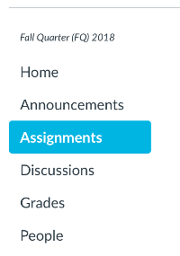

## Add Rules and Weights to Groups

Once you have groups set up, you can assign **weights** and **rules** to groups.

Assign weights to groups by clicking the ‘…’ menu.

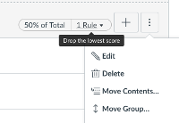

Rules (e.g. dropping an assignment) can be added to group by using individual group’s ‘…’ menus.

## Check the Gradebook to Confirm Rules Are Applied

Assuming you have assignments made and scores entered, confirm the rules you made are applied by checking the Gradebook.

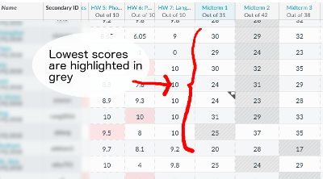

The Gradebook will show which scores are dropped by highlighting them (in grey).